# Chinese PhDs in the United States, Europe, and United Kingdom (1905-1962)

### Time Distribution

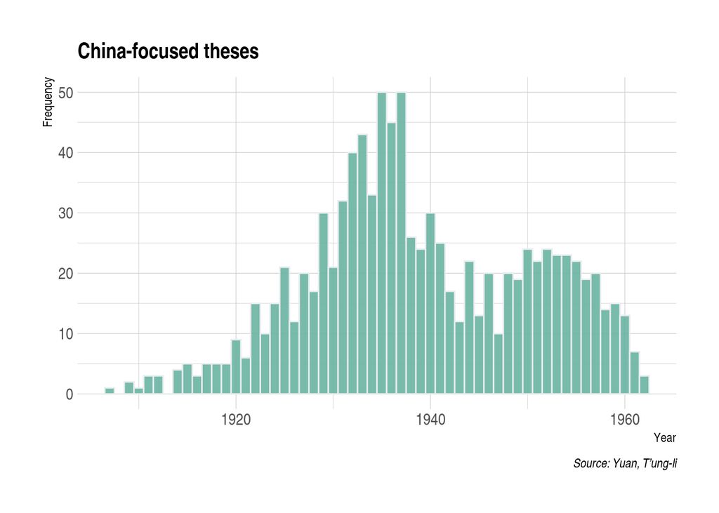

```r
library(hrbrthemes)
library(viridis)

# All Disciplines

china_theses_all %>%
  ggplot( aes(x=Degree_Year)) +
  geom_histogram( binwidth=1, fill="#69b3a2", color="#e9ecef", alpha=0.9) +
  ggtitle("Bin size = 1") +
  theme_ipsum() +
  theme(
    plot.title = element_text(size=15)
  ) +
  labs(title = "China-focused theses",
       x = "Year",
       y = "Frequency",
       caption = "Source: Yuan, T’ung-li")
```

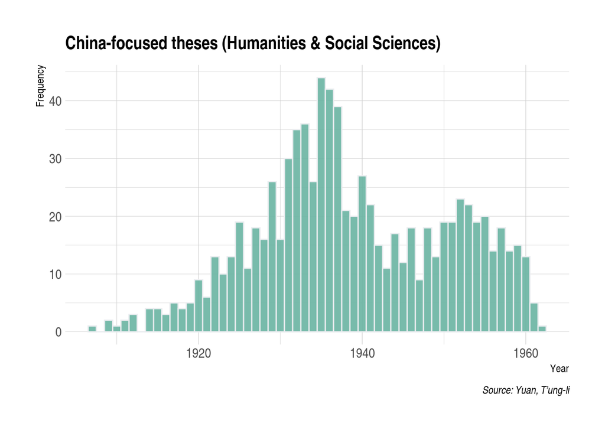

```r
# Humanities and Social Sciences

china_theses_all %>%
  filter(Field == "Humanities and social sciences") %>%
  ggplot( aes(x=Degree_Year)) +
  geom_histogram( binwidth=1, fill="#69b3a2", color="#e9ecef", alpha=0.9) +
  ggtitle("Bin size = 1") +
  theme_ipsum() +
  theme(
    plot.title = element_text(size=15)
  ) +
  labs(title = "China-focused theses (Humanities & Social Sciences)",
       x = "Year",
       y = "Frequency",
       caption = "Source: Yuan, T’ung-li")
```

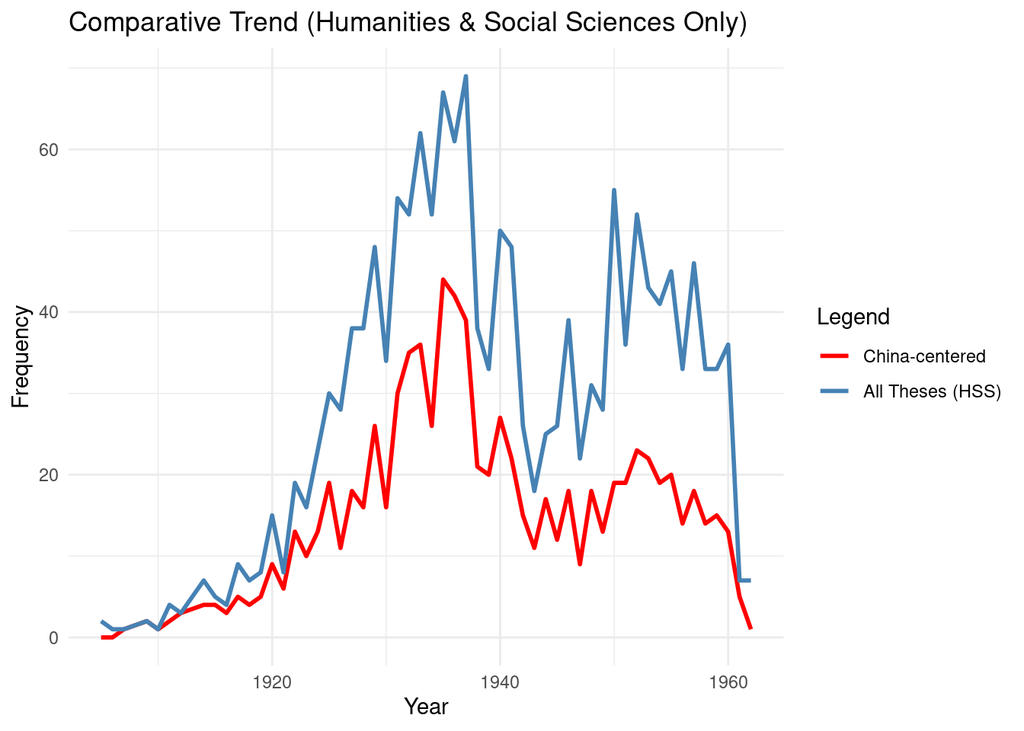

```r
# Comparative Trend

shs_all <- phd_all_master %>% filter(Field == "Humanities and social sciences") %>% group_by(Degree_Year) %>% count() %>% rename(TotalTheses = n)
shs_china  <- china_theses_all %>% filter(Field == "Humanities and social sciences") %>% group_by(Degree_Year) %>% count() %>% rename(ChinaTheses = n)
theses_year <- left_join(shs_all, shs_china)

theses_year <- theses_year %>%
  mutate(ChinaTheses = ifelse(is.na(ChinaTheses), 0, ChinaTheses))

theses_year <- theses_year %>% drop_na(Degree_Year)
theses_year <- theses_year %>% mutate(ratio = round(ChinaTheses/TotalTheses, 2))

ggplot(theses_year, aes(x = Degree_Year)) +
  geom_line(aes(y = ChinaTheses, color = "ChinaTheses"), size = 1) +
  geom_line(aes(y = TotalTheses, color = "TotalTheses"), size = 1) +
  labs(title = "Comparative Trend (Humanities & Social Sciences Only)",
       x = "Year",
       y = "Frequency") +
  scale_color_manual(name = "Legend",
                     values = c("ChinaTheses" = "red", "TotalTheses" = "steelblue"),
                     labels = c("ChinaTheses" = "China-centered", "TotalTheses" = "All Theses (HSS)")) +
  theme_minimal()
```

# Conclusion

This first document has focused on the doctoral dissertations themselves, remaining within the confines of a single data source: the original dissertation catalog compiled by Yuan Tongli. In the next documents, we will shift our attention to the authors of these dissertations—who were the Chinese PhDs, what were their backgrounds, and what trajectories did they follow after graduation — drawing on external datasets, including the Chinese University Students’ Datasets (CSUD-OS) compiled by the [Lee-Campbell Research Group](https://leecampbellgroup.blog/), as well as biographical entries from web-based knowledge platforms such as Wikipedia and Baidu.

# References

- **Yuan, T’ung-li** *A Guide to Doctoral Dissertations by Chinese Students in America, 1905–1960* Washington, D.C.: Published under the auspices of the Sino-American Cultural Society, 1961.
- **Yuan, T’ung-li** *Doctoral Dissertations by Chinese Students in Great Britain and Northern Ireland, 1916–1961* Taipei: Chinese Cultural Research Institute, 1963.
- **Yuan, T’ung-li** *A Guide to Doctoral Dissertations by Chinese Students in Continental Europe, 1907–1962* Taipei: Chinese Culture Quarterly Review, 1964.